# Drzewa decyzyjne

### Główne hiperparametry

- Kryterium podziału
  - Gini
  - Information Gain ("entropy")
- Maksymalna głębokość ("max_depth")
- Minimalna wielkość dzielonego zbioru ("min_samples_split" - minsplit w rpart)
- Minimalna wielkość zbioru w liściu ("min_samples_leaf" - minbucket w rpart)

# Charakterystyka zbioru titanic + podstawowy feature engineering

- One Hot Encoding na płci i tytule (Mr., Mrs., Miss., Master., Other)
- Drzewa są odporne na różnice rzędu wielkości w danych - brak potrzeby standaryzacji

Overview

Dataset info

| Number of variables | 11 |
| --- | --- |
| Number of observations | 887 |
| Total Missing (%) | 0.0% |
| Total size in memory | 46.0 KiB |
| Average record size in memory | 53.1 B |

Variables types

| Numeric | 5 |
| --- | --- |
| Categorical | 0 |
| Boolean | 6 |
| Date | 0 |
| Text (Unique) | 0 |
| Rejected | 0 |
| Unsupported | 0 |

Warnings

- `Fare` has 15 / 1.7% zeros Zeros

- `Parents/Children Aboard` has 674 / 76.0% zeros Zeros

- `Siblings/Spouses Aboard` has 604 / 68.1% zeros Zeros

- Dataset has 67 duplicate rows Warning

Variables

Age  
Numeric

| Distinct count | 89 |
| --- | --- |
| Unique (%) | 10.0% |
| Missing (%) | 0.0% |
| Missing (n) | 0 |
| Infinite (%) | 0.0% |
| Infinite (n) | 0 |

| Mean | 29.471 |
| --- | --- |
| Minimum | 0.42 |
| Maximum | 80 |
| Zeros (%) | 0.0% |

Toggle details

**Statistics**

Quantile statistics

| Minimum | 0.42 |
| --- | --- |
| 5-th percentile | 5 |
| Q1 | 20.25 |
| Median | 28 |
| Q3 | 38 |
| 95-th percentile | 55.85 |
| Maximum | 80 |
| Range | 79.58 |
| Interquartile range | 17.75 |

Descriptive statistics

| Standard deviation | 14.122 |
| --- | --- |
| Coef of variation | 0.47917 |
| Kurtosis | 0.29256 |
| Mean | 29.471 |
| MAD | 10.985 |
| Skewness | 0.44719 |
| Sum | 26141 |
| Variance | 199.43 |
| Memory size | 7.0 KiB |

**Histogram**

[figure not shown]

**Common Values**

| Value | Count | Frequency (%) |  |
| --- | --- | --- | --- |
| 22.0 | 39 | 4.4% |  |
| 28.0 | 37 | 4.2% |  |
| 18.0 | 36 | 4.1% |  |
| 21.0 | 34 | 3.8% |  |
| 24.0 | 34 | 3.8% |  |
| 19.0 | 33 | 3.7% |  |
| 30.0 | 33 | 3.7% |  |
| 27.0 | 26 | 2.9% |  |
| 29.0 | 25 | 2.8% |  |
| 23.0 | 25 | 2.8% |  |
| Other values (79) | 565 | 63.7% |  |

**Extreme Values**

Minimum 5 values

| Value | Count | Frequency (%) |  |
| --- | --- | --- | --- |
| 0.42 | 1 | 0.1% |  |
| 0.67 | 1 | 0.1% |  |
| 0.75 | 2 | 0.2% |  |
| 0.83 | 2 | 0.2% |  |
| 0.92 | 1 | 0.1% |  |

Maximum 5 values

| Value | Count | Frequency (%) |  |
| --- | --- | --- | --- |
| 70.0 | 2 | 0.2% |  |
| 70.5 | 1 | 0.1% |  |
| 71.0 | 2 | 0.2% |  |
| 74.0 | 1 | 0.1% |  |
| 80.0 | 1 | 0.1% |  |

Fare  
Numeric

| Distinct count | 248 |
| --- | --- |
| Unique (%) | 28.0% |
| Missing (%) | 0.0% |
| Missing (n) | 0 |
| Infinite (%) | 0.0% |
| Infinite (n) | 0 |

| Mean | 32.305 |
| --- | --- |
| Minimum | 0 |
| Maximum | 512.33 |
| Zeros (%) | 1.7% |

Toggle details

**Statistics**

Quantile statistics

| Minimum | 0 |
| --- | --- |
| 5-th percentile | 7.225 |
| Q1 | 7.925 |
| Median | 14.454 |
| Q3 | 31.137 |
| 95-th percentile | 112.56 |
| Maximum | 512.33 |
| Range | 512.33 |
| Interquartile range | 23.212 |

Descriptive statistics

| Standard deviation | 49.782 |
| --- | --- |
| Coef of variation | 1.541 |
| Kurtosis | 33.265 |
| Mean | 32.305 |
| MAD | 28.243 |
| Skewness | 4.7777 |
| Sum | 28655 |
| Variance | 2478.3 |
| Memory size | 7.0 KiB |

**Histogram**

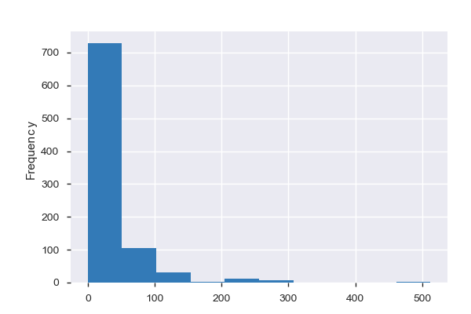

**Common Values**

| Value | Count | Frequency (%) |  |
| --- | --- | --- | --- |
| 8.05 | 43 | 4.8% |  |
| 13.0 | 42 | 4.7% |  |
| 7.8958 | 36 | 4.1% |  |
| 7.75 | 33 | 3.7% |  |
| 26.0 | 31 | 3.5% |  |
| 10.5 | 24 | 2.7% |  |
| 7.925 | 18 | 2.0% |  |
| 7.775 | 16 | 1.8% |  |
| 26.55 | 15 | 1.7% |  |
| 0.0 | 15 | 1.7% |  |
| Other values (238) | 614 | 69.2% |  |

**Extreme Values**

Minimum 5 values

| Value | Count | Frequency (%) |  |
| --- | --- | --- | --- |
| 0.0 | 15 | 1.7% |  |
| 4.0125 | 1 | 0.1% |  |
| 5.0 | 1 | 0.1% |  |
| 6.2375 | 1 | 0.1% |  |
| 6.4375 | 1 | 0.1% |  |

Maximum 5 values

| Value | Count | Frequency (%) |  |
| --- | --- | --- | --- |
| 227.525 | 4 | 0.5% |  |
| 247.5208 | 2 | 0.2% |  |
| 262.375 | 2 | 0.2% |  |
| 263.0 | 4 | 0.5% |  |
| 512.3292 | 3 | 0.3% |  |

Parents/Children Aboard  
Numeric

| Distinct count | 7 |
| --- | --- |
| Unique (%) | 0.8% |
| Missing (%) | 0.0% |
| Missing (n) | 0 |
| Infinite (%) | 0.0% |
| Infinite (n) | 0 |

| Mean | 0.38331 |
| --- | --- |
| Minimum | 0 |
| Maximum | 6 |
| Zeros (%) | 76.0% |

Toggle details

**Statistics**

Quantile statistics

| Minimum | 0 |
| --- | --- |
| 5-th percentile | 0 |
| Q1 | 0 |
| Median | 0 |
| Q3 | 0 |
| 95-th percentile | 2 |
| Maximum | 6 |
| Range | 6 |
| Interquartile range | 0 |

Descriptive statistics

| Standard deviation | 0.80747 |
| --- | --- |
| Coef of variation | 2.1065 |
| Kurtosis | 9.7231 |
| Mean | 0.38331 |
| MAD | 0.58253 |
| Skewness | 2.7412 |
| Sum | 340 |
| Variance | 0.652 |
| Memory size | 7.0 KiB |

**Histogram**

[figure not shown]

**Common Values**

| Value | Count | Frequency (%) |  |
| --- | --- | --- | --- |
| 0 | 674 | 76.0% |  |
| 1 | 118 | 13.3% |  |
| 2 | 80 | 9.0% |  |
| 5 | 5 | 0.6% |  |
| 3 | 5 | 0.6% |  |
| 4 | 4 | 0.5% |  |
| 6 | 1 | 0.1% |  |

**Extreme Values**

Minimum 5 values

| Value | Count | Frequency (%) |  |
| --- | --- | --- | --- |
| 0 | 674 | 76.0% |  |
| 1 | 118 | 13.3% |  |
| 2 | 80 | 9.0% |  |
| 3 | 5 | 0.6% |  |
| 4 | 4 | 0.5% |  |

Maximum 5 values

| Value | Count | Frequency (%) |  |
| --- | --- | --- | --- |
| 2 | 80 | 9.0% |  |
| 3 | 5 | 0.6% |  |
| 4 | 4 | 0.5% |  |
| 5 | 5 | 0.6% |  |
| 6 | 1 | 0.1% |  |

Pclass  
Numeric

| Distinct count | 3 |
| --- | --- |
| Unique (%) | 0.3% |
| Missing (%) | 0.0% |
| Missing (n) | 0 |
| Infinite (%) | 0.0% |
| Infinite (n) | 0 |

| Mean | 2.3055 |
| --- | --- |
| Minimum | 1 |
| Maximum | 3 |
| Zeros (%) | 0.0% |

Toggle details

**Statistics**

Quantile statistics

| Minimum | 1 |
| --- | --- |
| 5-th percentile | 1 |
| Q1 | 2 |
| Median | 3 |
| Q3 | 3 |
| 95-th percentile | 3 |
| Maximum | 3 |
| Range | 2 |
| Interquartile range | 1 |

Descriptive statistics

| Standard deviation | 0.83666 |
| --- | --- |
| Coef of variation | 0.36289 |
| Kurtosis | -1.2886 |
| Mean | 2.3055 |
| MAD | 0.76259 |
| Skewness | -0.62341 |
| Sum | 2045 |
| Variance | 0.7 |
| Memory size | 7.0 KiB |

**Histogram**

[figure not shown]

**Common Values**

| Value | Count | Frequency (%) |  |
| --- | --- | --- | --- |
| 3 | 487 | 54.9% |  |
| 1 | 216 | 24.4% |  |
| 2 | 184 | 20.7% |  |

**Extreme Values**

Minimum 5 values

| Value | Count | Frequency (%) |  |
| --- | --- | --- | --- |
| 1 | 216 | 24.4% |  |
| 2 | 184 | 20.7% |  |
| 3 | 487 | 54.9% |  |

Maximum 5 values

| Value | Count | Frequency (%) |  |
| --- | --- | --- | --- |
| 1 | 216 | 24.4% |  |
| 2 | 184 | 20.7% |  |
| 3 | 487 | 54.9% |  |

Sex_male  
Boolean

| Distinct count | 2 |
| --- | --- |
| Unique (%) | 0.2% |
| Missing (%) | 0.0% |
| Missing (n) | 0 |

| Mean | 0.646 |
| --- | --- |

| 1 | 573 |
| --- | --- |
| 0 | 314 |

Toggle details

| Value | Count | Frequency (%) |  |
| --- | --- | --- | --- |
| 1 | 573 | 64.6% |  |
| 0 | 314 | 35.4% |  |

Siblings/Spouses Aboard  
Numeric

| Distinct count | 7 |
| --- | --- |
| Unique (%) | 0.8% |
| Missing (%) | 0.0% |
| Missing (n) | 0 |
| Infinite (%) | 0.0% |
| Infinite (n) | 0 |

| Mean | 0.52537 |
| --- | --- |
| Minimum | 0 |
| Maximum | 8 |
| Zeros (%) | 68.1% |

Toggle details

**Statistics**

Quantile statistics

| Minimum | 0 |
| --- | --- |
| 5-th percentile | 0 |
| Q1 | 0 |
| Median | 0 |
| Q3 | 1 |
| 95-th percentile | 3 |
| Maximum | 8 |
| Range | 8 |
| Interquartile range | 1 |

Descriptive statistics

| Standard deviation | 1.1047 |
| --- | --- |
| Coef of variation | 2.1027 |
| Kurtosis | 17.798 |
| Mean | 0.52537 |
| MAD | 0.71549 |
| Skewness | 3.6868 |
| Sum | 466 |
| Variance | 1.2203 |
| Memory size | 7.0 KiB |

**Histogram**

[figure not shown]

**Common Values**

| Value | Count | Frequency (%) |  |
| --- | --- | --- | --- |
| 0 | 604 | 68.1% |  |
| 1 | 209 | 23.6% |  |
| 2 | 28 | 3.2% |  |
| 4 | 18 | 2.0% |  |
| 3 | 16 | 1.8% |  |
| 8 | 7 | 0.8% |  |
| 5 | 5 | 0.6% |  |

**Extreme Values**

Minimum 5 values

| Value | Count | Frequency (%) |  |
| --- | --- | --- | --- |
| 0 | 604 | 68.1% |  |
| 1 | 209 | 23.6% |  |
| 2 | 28 | 3.2% |  |
| 3 | 16 | 1.8% |  |
| 4 | 18 | 2.0% |  |

Maximum 5 values

| Value | Count | Frequency (%) |  |
| --- | --- | --- | --- |
| 2 | 28 | 3.2% |  |
| 3 | 16 | 1.8% |  |
| 4 | 18 | 2.0% |  |
| 5 | 5 | 0.6% |  |
| 8 | 7 | 0.8% |  |

Survived  
Boolean

| Distinct count | 2 |
| --- | --- |
| Unique (%) | 0.2% |
| Missing (%) | 0.0% |
| Missing (n) | 0 |

| Mean | 0.38557 |
| --- | --- |

| 0 | 545 |
| --- | --- |
| 1 | 342 |

Toggle details

| Value | Count | Frequency (%) |  |
| --- | --- | --- | --- |
| 0 | 545 | 61.4% |  |
| 1 | 342 | 38.6% |  |

Title_Miss.  
Boolean

| Distinct count | 2 |
| --- | --- |
| Unique (%) | 0.2% |
| Missing (%) | 0.0% |
| Missing (n) | 0 |

| Mean | 0.20519 |
| --- | --- |

| 0 | 705 |
| --- | --- |
| 1 | 182 |

Toggle details

| Value | Count | Frequency (%) |  |
| --- | --- | --- | --- |
| 0 | 705 | 79.5% |  |
| 1 | 182 | 20.5% |  |

Title_Mr.  
Boolean

| Distinct count | 2 |
| --- | --- |
| Unique (%) | 0.2% |
| Missing (%) | 0.0% |
| Missing (n) | 0 |

| Mean | 0.57835 |
| --- | --- |

| 1 | 513 |
| --- | --- |
| 0 | 374 |

Toggle details

| Value | Count | Frequency (%) |  |
| --- | --- | --- | --- |
| 1 | 513 | 57.8% |  |
| 0 | 374 | 42.2% |  |

Title_Mrs.  
Boolean

| Distinct count | 2 |
| --- | --- |
| Unique (%) | 0.2% |
| Missing (%) | 0.0% |
| Missing (n) | 0 |

| Mean | 0.14092 |
| --- | --- |

| 0 | 762 |
| --- | --- |
| 1 | 125 |

Toggle details

| Value | Count | Frequency (%) |  |
| --- | --- | --- | --- |
| 0 | 762 | 85.9% |  |
| 1 | 125 | 14.1% |  |

Title_Other  
Boolean

| Distinct count | 2 |
| --- | --- |
| Unique (%) | 0.2% |
| Missing (%) | 0.0% |
| Missing (n) | 0 |

| Mean | 0.03044 |
| --- | --- |

| 0 | 860 |
| --- | --- |
| 1 | 27 |

Toggle details

| Value | Count | Frequency (%) |  |
| --- | --- | --- | --- |
| 0 | 860 | 97.0% |  |
| 1 | 27 | 3.0% |  |

Correlations

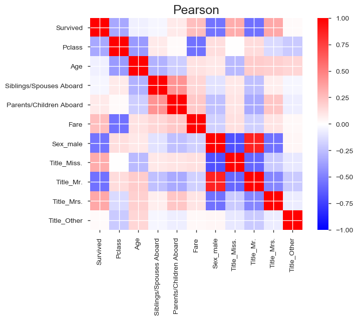

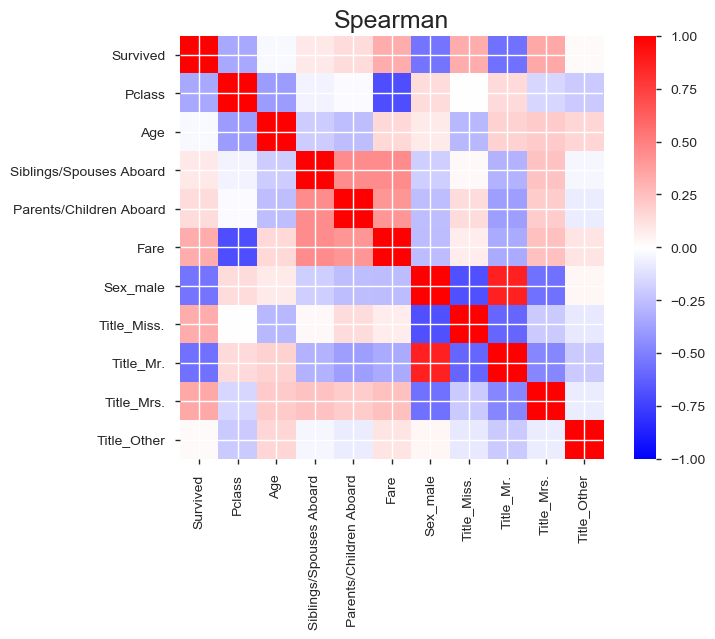

Sample

|  | Survived | Pclass | Age | Siblings/Spouses Aboard | Parents/Children Aboard | Fare | Sex_male | Title_Miss. | Title_Mr. | Title_Mrs. | Title_Other |
| --- | --- | --- | --- | --- | --- | --- | --- | --- | --- | --- | --- |
| 0 | 0 | 3 | 22.0 | 1 | 0 | 7.2500 | 1 | 0 | 1 | 0 | 0 |
| 1 | 1 | 1 | 38.0 | 1 | 0 | 71.2833 | 0 | 0 | 0 | 1 | 0 |
| 2 | 1 | 3 | 26.0 | 0 | 0 | 7.9250 | 0 | 1 | 0 | 0 | 0 |
| 3 | 1 | 1 | 35.0 | 1 | 0 | 53.1000 | 0 | 0 | 0 | 1 | 0 |
| 4 | 0 | 3 | 35.0 | 0 | 0 | 8.0500 | 1 | 0 | 1 | 0 | 0 |

## Domyślne hiperparametry

- Kryterium podziału - Gini
- Maksymalna głębokość - brak
- Minimalna wielkość dzielonego zbioru - 2
- Minimalna wielkość zbioru w liściu - 1

## Hiperparametry zaproponowane w pracy

- Kryterium podziału - porównam Gini i Information Gain ("entropy")
- Maksymalna głębokość - 21
- Minimalna wielkość dzielonego zbioru - 24
- Minimalna wielkość zbioru w liściu - 12

## Random Search

- Kryterium podziału - Gini
- Maksymalna głębokość w $\{1,2,\dots, 30\}$
- Minimalna wielkość dzielonego zbioru w$\{2,3,\dots, 60\}$
- Minimalna wielkość zbioru w liściu w $\{1,2,\dots, 60\}$

|  | Criterion | Max_depth | Min_samples_split | Min_samples_leaf |
| --- | --- | --- | --- | --- |
| Default | gini | None | 2.0 | 1.0 |
| Benchmarked | gini | 21 | 24.0 | 12.0 |
| BenchmarkedWithInfoGain | entropy | 21 | 24.0 | 12.0 |
| RandomSearch | gini | 4 | 27.0 | 16.0 |

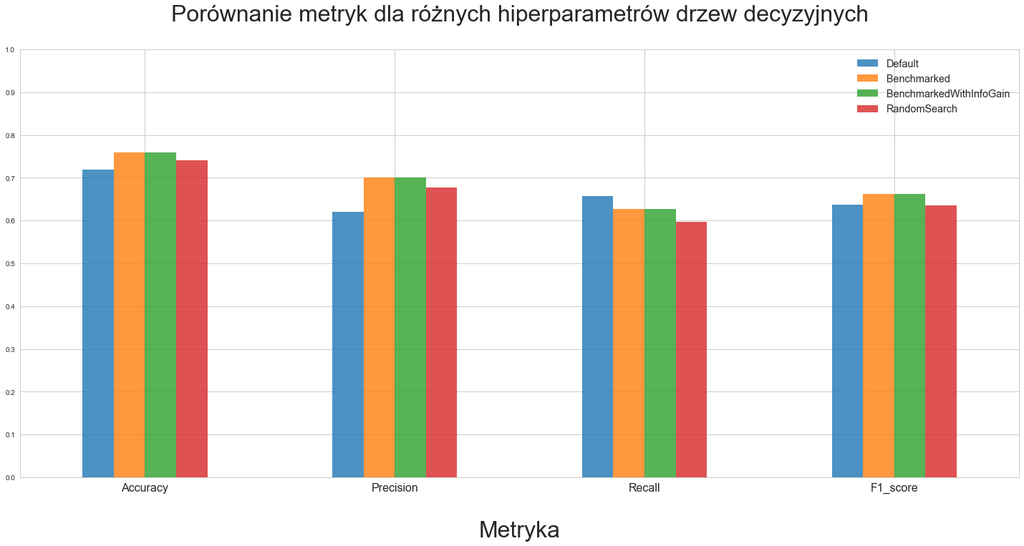

# Wizualizacje drzewa decyzyjnych

## Random Search

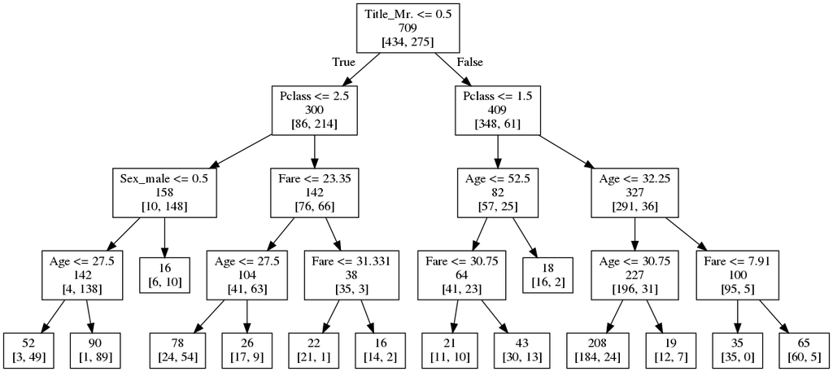

## Benchmark z pracy

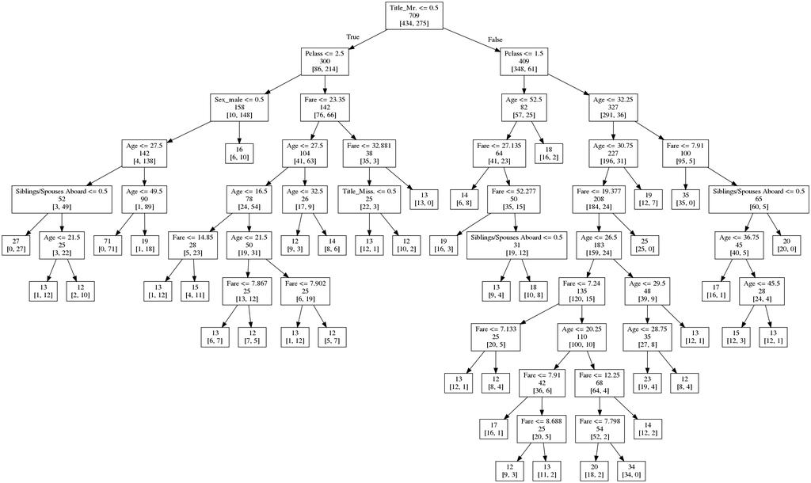

## Wartości domyślne

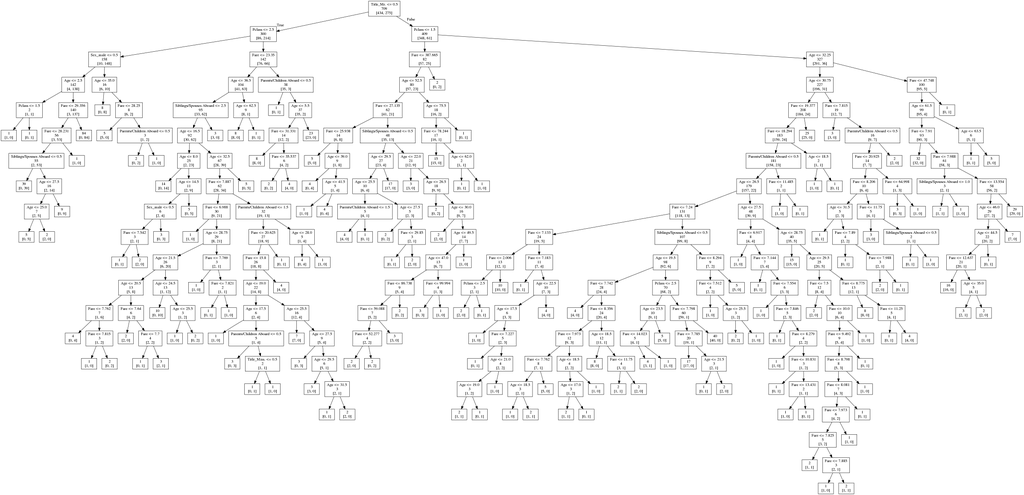

# Wnioski

## Manipulacja hiperparametrami

- Wzrost wartości Max_depth zwiększa model complexity
- Wzrost wartości Min_samples_split i Min_samples_leaf zmniejsza model complexity
- Zmiana kryterium Gini na Information Gain nie spowodowała żadnej zmiany - w większości przypadków mogę być one równoważne

## Porównanie drzew

- Wartości domyślne pakietu powodują znaczne przeuczenie się modelu
- Wartości domyślne pochodzące z pracy dają najlepsze wyniki, random search czasami znajduje lepszy zestaw parametrów, ale przy losowych podziałach na zbiór treningowy i testowy lepiej radzą sobie parametry z pracy.